# P09M01L01

## Module 01: Data Viz Lessons 2

### Lesson 01: Introduction to Data Visualization

> In this lesson, you will learn the main data visualizations used for univariate and bivariate analyses. As well as the visualizations that are used for when you you want to compare more variables.

#### 01. Data Visualization Introduction

**Book**

`The visual display of quantitative information` by Edward Tufte

- When we're talking about data visualization, we mean the visual display of quantitative information.
- First, I'll cover fundamentals and design principles.
- Then, you'll learn how to actually make visualizations.

#### 02. Why Do We Use Data Visualizations?

1. Why are data visualizations more useful for delivering insight than just using summary statistics?
2. What plot do you build in a given situation?
3. Creating data dashboards

#### 03. Motivation for Data Visualization

Anscombe's quartet comprises of four datasets, and is rather famous. Why? You'll find out in this exercise.

**Summary Statistics**

For each of the four datasets：

- Compute the mean and variance of both x and y
- Compute the correlation coefficient between x and y

```python
import seaborn as sns
import matplotlib.pyplot as plt
```

```python
anscombe = sns.load_dataset("anscombe")
```

```python
anscombe.groupby('dataset').mean()
```

| dataset | x | y |
| --- | --- | --- |
| I | 9.0 | 7.500909 |
| II | 9.0 | 7.500909 |
| III | 9.0 | 7.500000 |
| IV | 9.0 | 7.500909 |

```python
anscombe.groupby('dataset').var()
```

| dataset | x | y |
| --- | --- | --- |
| I | 11.0 | 4.127269 |
| II | 11.0 | 4.127629 |
| III | 11.0 | 4.122620 |
| IV | 11.0 | 4.123249 |

```python
anscombe.groupby('dataset').corr()
```

| dataset |  | x | y |
| --- | --- | --- | --- |
| I | x | 1.000000 | 0.816421 |
|  | y | 0.816421 | 1.000000 |
| II | x | 1.000000 | 0.816237 |
|  | y | 0.816237 | 1.000000 |
| III | x | 1.000000 | 0.816287 |
|  | y | 0.816287 | 1.000000 |
| IV | x | 1.000000 | 0.816521 |
|  | y | 0.816521 | 1.000000 |

**Data Visualization**

Using Seaborn, visualize all four datasets.

- hint: use sns.FacetGrid combined with plt.scatter`

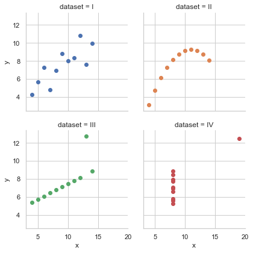

```python
sns.set(style='whitegrid')
g = sns.FacetGrid(anscombe, col='dataset', hue='dataset', col_wrap=2)
g.map(plt.scatter, 'x', 'y')
plt.show();
```

#### 04. Further Motivation

Beyond Anscombe's Quartet More recently [Alberto Cairo](http://albertocairo.com/) created the [Datasaurus](https://www.autodeskresearch.com/publications/samestats) dataset, which is **amazingly insightful and artistic**, but is built on the same idea that you just discovered. You can find the full dataset, and the visualizations on the **Datasaurus** [link](https://www.autodeskresearch.com/sites/default/files/The%20Datasaurus%20Dozen.zip).

```python
import pandas as pd
```

```python
datasaurus = pd.read_csv('DatasaurusDozen.tsv', sep="\t")
```

```python
datasaurus.groupby('dataset').mean()
```

| dataset | x | y |
| --- | --- | --- |
| away | 54.266100 | 47.834721 |
| bullseye | 54.268730 | 47.830823 |
| circle | 54.267320 | 47.837717 |
| dino | 54.263273 | 47.832253 |
| dots | 54.260303 | 47.839829 |
| h_lines | 54.261442 | 47.830252 |
| high_lines | 54.268805 | 47.835450 |
| slant_down | 54.267849 | 47.835896 |
| slant_up | 54.265882 | 47.831496 |
| star | 54.267341 | 47.839545 |
| v_lines | 54.269927 | 47.836988 |
| wide_lines | 54.266916 | 47.831602 |
| x_shape | 54.260150 | 47.839717 |

```python
datasaurus.groupby('dataset').var()
```

| dataset | x | y |
| --- | --- | --- |
| away | 281.227029 | 725.749775 |
| bullseye | 281.207393 | 725.533372 |
| circle | 280.898024 | 725.226844 |
| dino | 281.069988 | 725.515961 |
| dots | 281.156953 | 725.235215 |
| h_lines | 281.095333 | 725.756931 |
| high_lines | 281.122364 | 725.763490 |
| slant_down | 281.124206 | 725.553749 |
| slant_up | 281.194420 | 725.688605 |
| star | 281.197993 | 725.239695 |
| v_lines | 281.231512 | 725.638809 |
| wide_lines | 281.232887 | 725.650560 |
| x_shape | 281.231481 | 725.224991 |

```python
datasaurus.groupby('dataset').corr()
```

| dataset |  | x | y |
| --- | --- | --- | --- |
| away | x | 1.000000 | -0.064128 |
|  | y | -0.064128 | 1.000000 |
| bullseye | x | 1.000000 | -0.068586 |
|  | y | -0.068586 | 1.000000 |
| circle | x | 1.000000 | -0.068343 |
|  | y | -0.068343 | 1.000000 |
| dino | x | 1.000000 | -0.064472 |
|  | y | -0.064472 | 1.000000 |
| dots | x | 1.000000 | -0.060341 |
|  | y | -0.060341 | 1.000000 |
| h_lines | x | 1.000000 | -0.061715 |
|  | y | -0.061715 | 1.000000 |
| high_lines | x | 1.000000 | -0.068504 |
|  | y | -0.068504 | 1.000000 |
| slant_down | x | 1.000000 | -0.068980 |
|  | y | -0.068980 | 1.000000 |
| slant_up | x | 1.000000 | -0.068609 |
|  | y | -0.068609 | 1.000000 |
| star | x | 1.000000 | -0.062961 |
|  | y | -0.062961 | 1.000000 |
| v_lines | x | 1.000000 | -0.069446 |
|  | y | -0.069446 | 1.000000 |
| wide_lines | x | 1.000000 | -0.066575 |
|  | y | -0.066575 | 1.000000 |
| x_shape | x | 1.000000 | -0.065583 |
|  | y | -0.065583 | 1.000000 |

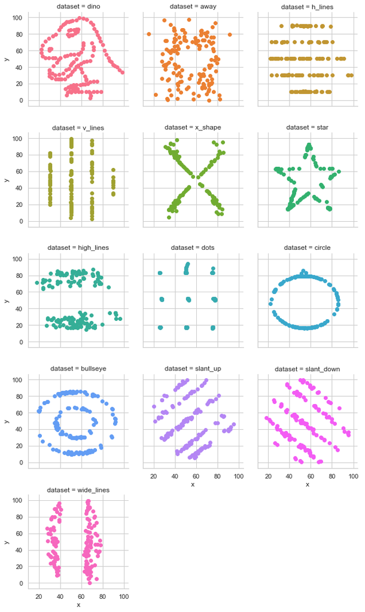

```python
sns.set(style='whitegrid')
g = sns.FacetGrid(datasaurus, col='dataset', hue='dataset', col_wrap=3)
g.map(plt.scatter, 'x', 'y')
plt.show();
```

#### 05. Data Types Review

Data Types

- If you are in the Business Analytics or Data Foundations Nanodegree program, you can review data types in the lesson "Video: Data Types (Quantitative vs. Categorical)" back in the Introduction to Data section.
- If you are in the Business Analyst Nanodegree program, you can review data types in the lesson "Introduction to Data Types" in the Data Wrangling section.
- If you are in the Data Analyst Nanodegree program, you can review data types in the lesson "Data Types and Operators" in the Introduction to Python section.

#### 06. Identifying Data Types

1. Identify correct data types for the following example dataset:

| Survey | Height (cm) | Sex | Scratches (cat) |
| --- | --- | --- | --- |
| 1 | 173.57 | F | 1 |
| 5 | 199.13 | M | 0 |
| 4 | 186.41 | M | 1 |
| 2 | 169.98 | F | 3 |
| 4 | 164.39 | F | 2 |
| 3 | 170.67 | M | 5 |

[figure not shown]

- Doctor Visits per Year - Ordinal
- Life Expectancy - Continuous
- Spending per Person - Continuous
- Has Universal Healthcare - Categorical

#### 07. Univariate Plots

For **quantitative data**, if we are just looking at one column worth of data, we have four common visuals:

1. Histogram
2. Normal Quantile Plot
3. Stem and Leaf Plot
4. Box and Whisker Plot

In most cases, you will want to use a **histogram**.

For **categorical data**, if we are looking at just one variable (column), we have three common visuals:

1. Bar Chart
2. Pie Chart
3. Pareto Chart

In most cases, you will want to use a **bar chart**.

#### 08. Univariate Plots

`pass`

#### 09. Scatter Plots

Scatter plots are a common visual for comparing two quantitative variables. A common summary statistic that relates to a scatter plot is the **correlation coefficient** commonly denoted by r.

Though there are a [few different ways](http://www.statisticssolutions.com/correlation-pearson-kendall-spearman/) to measure correlation between two variables, the most common way is with [Pearson's correlation coefficient](https://en.wikipedia.org/wiki/Pearson_correlation_coefficient). Pearson's correlation coefficient provides the:

1. Strength
2. Direction

of a **linear relationship**. [Spearman's Correlation Coefficient](https://en.wikipedia.org/wiki/Spearman%27s_rank_correlation_coefficient) does not measure linear relationships specifically, and it might be more appropriate for certain cases of associating two variables.

#### 10. Quizzes On Scatter Plots

```python
df = pd.read_excel('quizzes-data-1.xlsx')
```

```python
df.head()
```

|  | Temp | Sales | Unnamed: 2 | MPG | Weight (1,000 lbs) | Unnamed: 5 | Unnamed: 6 | x | y | x.1 | y.1 | x.2 | y.2 |
| --- | --- | --- | --- | --- | --- | --- | --- | --- | --- | --- | --- | --- | --- |
| 0 | 14.2 | 215.0 | NaN | 31 | 1650 | NaN | NaN | 1.0 | 1.0 | 1.0 | 7.0 | -1.0 | 1.0 |
| 1 | 16.4 | 325.0 | NaN | 31 | 1800 | NaN | NaN | 2.0 | 2.0 | 2.0 | 6.0 | -2.0 | 4.0 |
| 2 | 11.9 | 185.0 | NaN | 34 | 1900 | NaN | NaN | 3.0 | 3.0 | 3.0 | 5.0 | -3.0 | 9.0 |
| 3 | 15.2 | 332.0 | NaN | 22 | 2200 | NaN | NaN | 4.0 | 4.0 | 4.0 | 4.0 | -4.0 | 16.0 |
| 4 | 18.5 | 406.0 | NaN | 24 | 2250 | NaN | NaN | 5.0 | 5.0 | 5.0 | 3.0 | -5.0 | 25.0 |

```python
df.columns
```

```
Index(['Temp', 'Sales', 'Unnamed: 2', 'MPG', 'Weight (1,000 lbs)',
       'Unnamed: 5', 'Unnamed: 6', 'x', 'y', 'x.1', 'y.1', 'x.2', 'y.2'],
      dtype='object')
```

```python
df.drop(['Unnamed: 2', 'Unnamed: 5', 'Unnamed: 6'], axis=1, inplace=True)
```

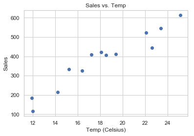

```python
plt.scatter(x=df.Temp, y=df.Sales)
plt.title("Sales vs. Temp")
plt.xlabel("Temp (Celsius)")
plt.ylabel("Sales");
```

```python
df.Temp.corr(df.Sales)
```

```
0.9590202560030179
```

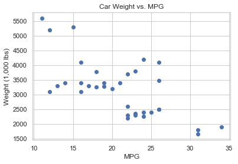

```python
plt.scatter(x=df.MPG, y=df['Weight (1,000 lbs)'])
plt.title('Car Weight vs. MPG')
plt.xlabel('MPG')
plt.ylabel('Weight (1,000 lbs)');
```

```python
df.MPG.corr(df['Weight (1,000 lbs)'])
```

```
-0.6693141003674267
```

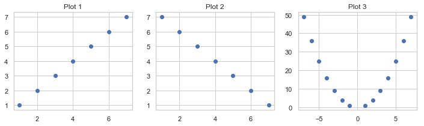

```python
fig, (ax1, ax2, ax3) = plt.subplots(nrows=1, ncols=3, figsize=(12, 3))
ax1.scatter(x=df.x, y=df.y)
ax1.set_title('Plot 1')
ax2.scatter(x=df["x.1"], y=df["y.1"])
ax2.set_title('Plot 2')
ax3.scatter(x=df["x.2"], y=df["y.2"])
ax3.set_title('Plot 3')
plt.show();
```

```python
df['x.2'].corr(df['y.2'])
```

```
0.0
```

#### 11. Correlation Coefficients

**Correlation Coefficients**

Correlation coefficients provide a measure of the **strength** and **direction** of a **linear** relationship.

We can tell the direction based on whether the correlation is **positive** or **negative**.

A rule of thumb for judging the strength:

- **Strong**: $\small 0.7 \le |r| \le 1.0$
- **Moderate**: $\small 0.3 \le |r| \le 0.7$
- **Weak**: $\small 0.0 \le |r| \le 0.3$

**Calculation of the Correlation Coefficient**

$$r = \frac{\displaystyle\sum_{i=1}^n(x_i - \bar{x})(y_i - \bar{y})}{\sqrt{(\sum(x_i-\bar{x}))}\sqrt{(\sum(y_i-\bar{y}))}}$$

It can also be calculated in Excel and other spreadsheet applications using **CORREL(col1, col2)**, where col1 and col2 are the two columns you are looking to compare to one another.

#### 12. Correlation Coefficient Quizzes

`pass`

#### 13. Line Plots

Line plots are a common plot for viewing data over time. These plots allow us to quickly identify overall trends, seasonal occurrences, peaks, and valleys in the data. You will commonly see these used in looking at stock prices over time, but really tracking anything over time can be easily viewed using these plots.

#### 14. What is the Question?

What is the Question? The key to building great data visualizations is in aiming them at answering the questions you want answered. This presentation gave a number of ways to show the exact same data in different ways depending on the question you want to answer.

You can download the data using the button below. You can also find the data in a Google Sheet [here](https://docs.google.com/spreadsheets/d/1YBTluJIqxp-yK6Az87i4lobq8gpNHXc_PSx_toKVWUM/edit?usp=sharing).

```python
df = pd.read_excel('product-data.xlsx')
```

```python
df.head()
```

|  | Date | Sales | Prod 1 | Prod 2 | Prod 3 | Total |
| --- | --- | --- | --- | --- | --- | --- |
| 0 | Jan | 200 | 100 | 80 | 20 | 200 |
| 1 | Feb | 350 | 200 | 30 | 120 | 350 |
| 2 | Mar | 420 | 210 | 120 | 90 | 420 |
| 3 | Apr | 380 | 100 | 100 | 180 | 380 |
| 4 | May | 800 | 300 | 190 | 310 | 800 |

```python
df.columns
```

```
Index(['Date', 'Sales', 'Prod 1 ', 'Prod 2', 'Prod 3', 'Total'], dtype='object')
```

```python
df.rename({'Prod 1 ': 'Prod 1'}, axis=1, inplace=True)
```

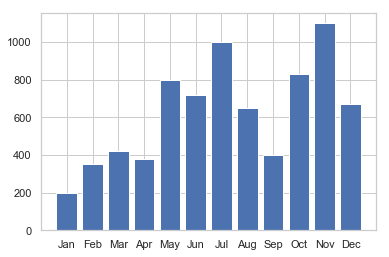

```python
plt.bar(df.Date, df.Sales);
```

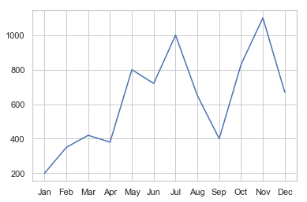

```python
plt.plot(df.Date, df.Sales);
```

#### 15. What About with More Than Two Variables?

What About with More Than Two Variables?

Here you were able to see a number of different visuals for comparing more than two variables - there isn't a right answer in choosing these plots - and this is where the science can become more of an art. In the next quiz, you will see why we might choose one plotting method vs. another using some of the same data from the video.

#### 16. Multiple Variables Quiz

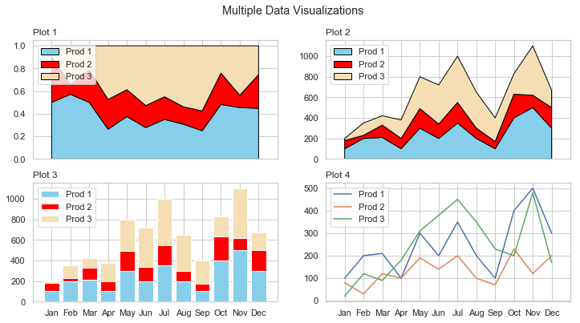

```python
fig, axs = plt.subplots(nrows=2, ncols=2, figsize=(12, 6), sharex='all')

axs[0, 0].stackplot(df.Date, df['Prod 1']/df.Total, df['Prod 2']/df.Total, df['Prod 3']/df.Total,
              labels=['Prod 1', 'Prod 2', 'Prod 3'],
              colors=['skyblue', 'red', 'wheat'],
             edgecolors=['black', 'black', 'black'])
axs[0, 0].set_title("Plot 1", loc='left')
axs[0, 0].legend(loc='upper left')

axs[0, 1].stackplot(df.Date, df['Prod 1'], df['Prod 2'], df['Prod 3'],
              labels=['Prod 1', 'Prod 2', 'Prod 3'],
              colors=['skyblue', 'red', 'wheat'],
             edgecolors=['black', 'black', 'black'])
axs[0, 1].set_title("Plot 2", loc='left')
axs[0, 1].legend(loc='upper left')

axs[1, 0].bar(df.Date, df['Prod 1'], color='skyblue', label='Prod 1')
axs[1, 0].bar(df.Date, df['Prod 2'], color='red', label='Prod 2', bottom=df['Prod 1'])
axs[1, 0].bar(df.Date, df['Prod 3'], color='wheat', label='Prod 3', bottom=df['Prod 1']+df['Prod 2'])
axs[1, 0].set_title("Plot 3", loc='left')
axs[1, 0].legend()

axs[1, 1].plot(df.Date, df['Prod 1'], label='Prod 1')
axs[1, 1].plot(df.Date, df['Prod 2'], label='Prod 2')
axs[1, 1].plot(df.Date, df['Prod 3'], label='Prod 3')
axs[1, 1].set_title("Plot 4", loc='left')
axs[1, 1].legend()

fig.suptitle("Multiple Data Visualizations");
```

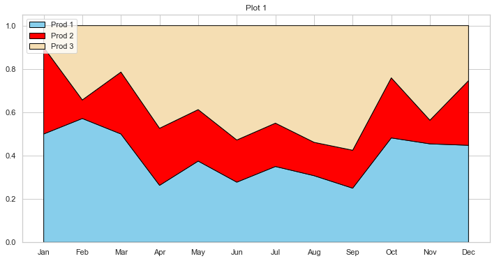

```python
plt.figure(figsize=(12, 6))
plt.stackplot(df.Date, df['Prod 1']/df.Total, df['Prod 2']/df.Total, df['Prod 3']/df.Total,
              labels=['Prod 1', 'Prod 2', 'Prod 3'],
              colors=['skyblue', 'red', 'wheat'],
             edgecolors=['black', 'black', 'black'])
plt.title("Plot 1")
plt.legend(loc='upper left')
plt.show();
```

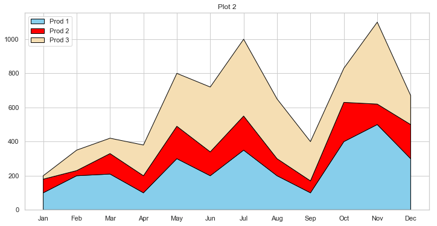

```python
plt.figure(figsize=(12, 6))
plt.stackplot(df.Date, df['Prod 1'], df['Prod 2'], df['Prod 3'],
              labels=['Prod 1', 'Prod 2', 'Prod 3'],
              colors=['skyblue', 'red', 'wheat'],
             edgecolors=['black', 'black', 'black'])
plt.title("Plot 2")
plt.legend(loc='upper left')
plt.show();
```

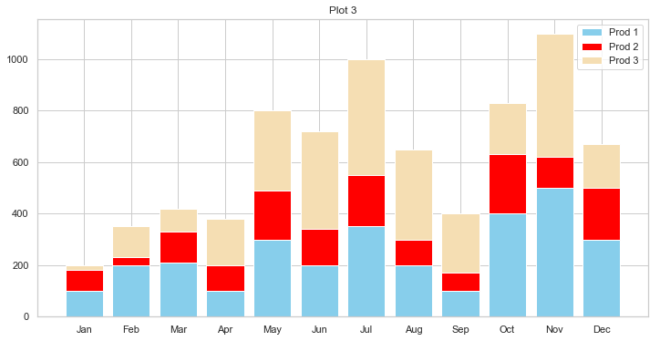

```python
fig, ax = plt.subplots(figsize=(12, 6))

ax.bar(df.Date, df['Prod 1'], color='skyblue', label='Prod 1')
ax.bar(df.Date, df['Prod 2'], color='red', label='Prod 2', bottom=df['Prod 1'])
ax.bar(df.Date, df['Prod 3'], color='wheat', label='Prod 3', bottom=df['Prod 1']+df['Prod 2'])

plt.title("Plot 3")
plt.legend()
plt.show();
```

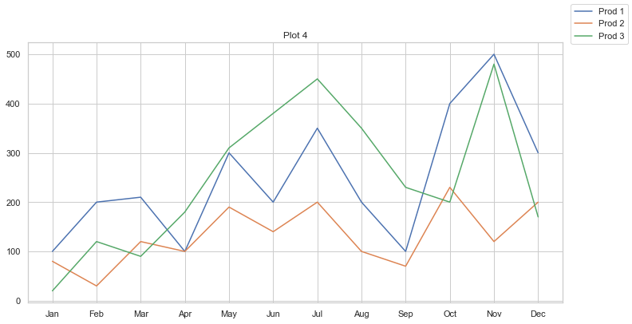

```python
fig, ax = plt.subplots(figsize=(12, 6))
ax.plot(df.Date, df['Prod 1'], label='Prod 1')
ax.plot(df.Date, df['Prod 2'], label='Prod 2')
ax.plot(df.Date, df['Prod 3'], label='Prod 3')

plt.title("Plot 4")
fig.legend()
plt.show();
```

#### 17. Why Data Dashboards

Dashboards allow you to interact with your data, and view multiple aspects of your data all in the same visual environment.

#### 18. Introduction to Data Dashboards

Hans Rosling shows an amazing visualization that incorporates many variables all at once.

#### 19. Quiz On Visual Encodings

`pass`

#### 20. Recap

In this lesson:

1. You motivated the need for data visualization by showing that summary statistics don't tell the full story. You saw datasets where the summary statistics were the same, but the actual data were very different!
2. You did a review of data types. In general there are quantitative and categorical variables. Quantitative variables can be either discrete or continuous, while categorical variables are either ordinal or nominal.
3. You looked at univariate plots. In most cases a histogram should be used for quantitative data, while a bar chart should be used for categorical data. There are some cases where you might use one of the other plots.
4. You then looked at bivariate plots, where you were comparing two variables to one another. Scatter plots are the most common way to visualize two quantitative variables, while a line chart is common for data that you are watching over time. If you are comparing two categorical variables, the best choice is probably a side-by-side bar chart.
5. You learned about correlation coefficients, which provide the strength and direction of linear relationships. You learned a rule of thumb for determining whether the relationship between two quantitative variables is strong, moderate, or weak.
6. You then looked at cases where we had more than two variables. You learned that using these plots effectively is about building the plot that helps you see the insight that answers the question you have.
7. You gained some insight into visual encodings and data dashboards, which will be a part of the next lessons!

#### 21. What's Next?

Visual Encodings are the way we show our variables in a plot. Design component for your visual:

- x and y axis
- color
- bars or points or lines
- shapes or textures